# Support Vector Machines

The term Support Vector Machines (SVM's) is sometimes used loosely to refer to three methods:

- Maximal margin classifier,
- Support vector classifier,
- Support vector machine.

Each are an extension of the previous method, allowing them to be applied to a broader range of cases.

Support Vector Machines (SVM) are a common discriminative algorithm, well suited to *complex* small- to medium sized datasets<sup>Géron</sup>, which aim to find a hyperplane that provides the maximum margin of separation between classes of objects.

They can be used for both classification and regression.

# Introduction

To demonstrate SVM's I'll be using Fisher's (or Anderson's) Iris flowers dataset<sup>Fisher</sup>.

```python
Image("1_2b9TA6i27eGjeDQE9qUaEg.png") # Image from:
```

[output not shown]

The data set consists of 50 samples from each of three species of Iris, with four features measured from each sample: the length and the width of the sepals and petals, in centimeters.

[output not shown]

```python
display(Image("03_iris.png")) # Image from: https://www.ritchieng.com/machine-learning-iris-dataset/
iris_df.head()
```

[output not shown]

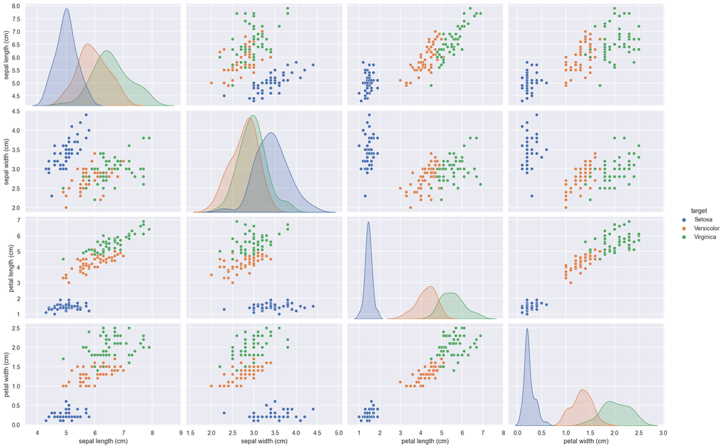

```python
sns.pairplot(iris_vis, hue="target", height=3, aspect = 1.5)
plt.show()
```

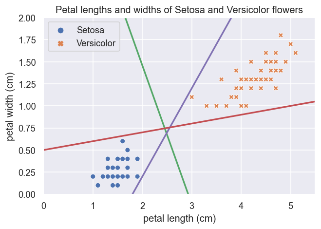

```python
set_versi_plot()
plt.plot(x0, decision_boundary, "g-", linewidth=2)
plt.plot(x0, pred_2, "m-", linewidth=2)
plt.plot(x0, pred_3, "r-", linewidth=2)
plt.show()
```

Here the middle thick line is a **hyperplane** and the dashed outer lines are the edges of the **Margin**.

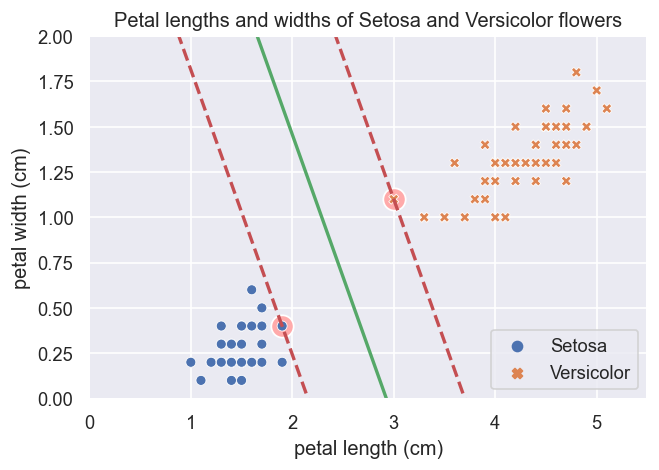

```python
plot_svc_decision_boundary(svm_clf, 0, 5.5)
set_versi_plot()
plt.show()
```

## What is a Hyperplane?

In *p*-dimensional space, a hyperplane is a flat affine (does not need to pass through the origin) subspace of dimension p-1.

**Examples**

```python
three_dim()
```

[output not shown]

*Two-dimensions*: $\beta_0 + \beta_1X_1 + \beta_2X_2 = 0$

*Three-dimensions*: $\beta_0 + \beta_1X_1 + \beta_2X_2 + \beta_3X_3 = 0$

*P-dimensions*: $\beta_0 + \beta_1X_1 + \beta_2X_2 + ... + \beta_pX_p = 0$

If $X = (X_1, ..., X_p)^T$ satisfies above, then it is a point on the hyperplane.

If $\beta_0 + \beta_1X_1 + \beta_2X_2 + ... + \beta_pX_p > 0$ it lies on one side of the hyperplane and $\beta_0 + \beta_1X_1 + \beta_2X_2 + ... + \beta_pX_p < 0$ on the other. In-other-words p-dimensional space is dividided into two halves.

### Classifying data using a separating hyperplane

We aim to classify an $n \times p$ matrix of $n$ observations in $p$ dimensional space with these observations falling into two classes $y_1,...,y_n \in \{-1,1\}$.

If we were to perfectly separate the classes the hyperplane would have the property that

$\beta_0 + \beta_1X_{i1} + \beta_2X_{i2} + ... + \beta_pX_{ip} > 0$ if $y_i = 1$,

and

$\beta_0 + \beta_1X_{i1} + \beta_2X_{i2} + ... + \beta_pX_{ip} < 0$ if $y_i = -1$.

For new test observations $x^*$, we would assign it to class 1 if $f(x^*)$ is positive and class -1 if negative. Furthermore the magnitude of $f(x^*)$ can be used to indicate how far the point lies from the hyperplane.

## Exercises

[THEORY BASED!]

# Maximal Margin Classifier

We need a reasonable way of constucting a hyperplane, out of the possible choices.

Maximumal margin hyperplanes look at getting the hyperplane that is the furthest from the training obeservations - we compute the perpendicular distance from each training observation to a given separating hyperplane. The maximal margin hyperplane is the separating hyperplane for which the margin is largest.

We hope the classifier with a large margin on the training data will generalise well to unseen test observations.

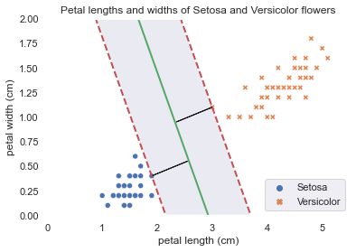

```python
plot_svc_margin(svm_clf, 0, 5.5)
set_versi_plot()
plt.show()
```

We can see below there are two equidistant points from the maximal margin hyperplane, lying on the dashed lines. There observations are called *Support Vectors*, as if these moved so would the hyperplane.

The maximal margin hyperplane only depends on these support vectors, meaning other points could be moved without the hyperplane moving.

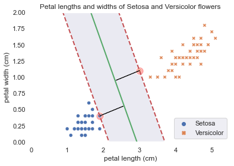

```python
plot_svc_margin(svm_clf, 0, 5.5, highlight=True)
set_versi_plot()
plt.show()
```

This maximal margin hyperplane is the solution to the optemisation problem for choosing $\beta_0,\beta_1, ...\beta_p$ to maximise $M$,

subject to $\sum^p_{j=1}\beta^2_j = 1$,

$\beta_0 + \beta_1x_{i1} + \beta_2x_{i2} + ... + \beta_pX_{ip} \geq M \quad \forall i = 1,...,n$

The constraints above just ensure that each observation is on the correct side of the hyperplane and at least a distance $M$ from the hyperplane; meaning $M$ represents our hyperplane.

### Limitations

However this method is sensitive to outliers. In figure X, we can see that the reliance on a small number of observations means there is now a small margin. We want to be confident that a distance from the hyperlane is a measure of our confidence in its classificaion, and that we have no overfit to our training data.

In other cases, no exact linear separating hyperplane exists (so no solution to $M > 0$). Therefore we may want to use a hyperplane that *almost* separates the two classes, allowing some errors, using a *soft margin* (Support Vector Classifier).

Furthermore, if $P$ is large, this approach often leads to overfitting.

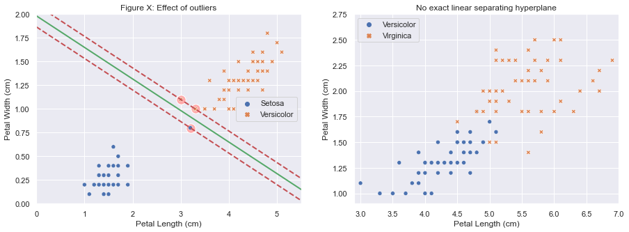

```python
hard_margin_limits()
```

## Exercises

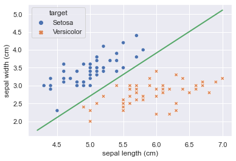

```python
# QUESTION 2
exersise_ = iris_vis[["sepal length (cm)", "sepal width (cm)", "target"]]
exersise_ = exersise_[exersise_.target != "Virginica"]

X = exersise_[["sepal length (cm)", "sepal width (cm)"]].values
y = le.transform(exersise_[["target"]].values.ravel())

# SVM Classifier model
svm_clf = SVC(kernel="linear", C=float("inf"))
svm_clf.fit(X, y)
w = svm_clf.coef_[0]
b = svm_clf.intercept_[0]

x0 = np.linspace(4.2, 7, 200)
decision_boundary = -w[0]/w[1] * x0 - b/w[1]

plt.plot(x0, decision_boundary, "g-", linewidth=2)
g = sns.scatterplot(data=exersise_, x = "sepal length (cm)",
                y = "sepal width (cm)", hue="target",
                style = "target")
```

## Exercise Answers

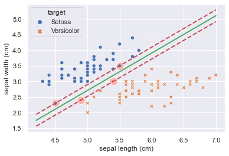

```python
# ANSWERS 2
exersise_ = iris_vis[["sepal length (cm)", "sepal width (cm)", "target"]]
exersise_ = exersise_[exersise_.target != "Virginica"]

X = exersise_[["sepal length (cm)", "sepal width (cm)"]].values
y = le.transform(exersise_[["target"]].values.ravel())

# SVM Classifier model
svm_clf = SVC(kernel="linear", C=float("inf"))
svm_clf.fit(X, y)
w = svm_clf.coef_[0]
b = svm_clf.intercept_[0]

x0 = np.linspace(0, 5.5, 200)
decision_boundary = -w[0]/w[1] * x0 - b/w[1]
plot_svc_decision_boundary(svm_clf, 4.2, 7)
g = sns.scatterplot(data=exersise_, x = "sepal length (cm)",
                y = "sepal width (cm)", hue="target",
                style = "target")
```

# Support Vector Classifier (SVC)

SVC's are a generalisation and extension of the maximal margin classifier so it can be applied to a broader range of cases<sup>James</sup>.

In practice they are more robust to individual observations and better classify most training observations than the Maximal Margin Classifier. This is because they take the approach it is better to missclassify some training examples in order to do a better job classifying the rest.

This is called a *soft margin* as it allows some violations by the training data by a small subset of training observation, not only on the wrong side of the margin, but wrong side of the hyperplane.

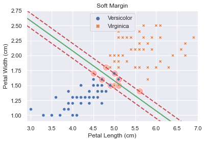

```python
soft_margin("Soft Margin", hyperplane=True)
plt.show()
```

This is the solution to the optimisation problem for choosing $\beta_0,\beta_1, ...\beta_p$, with a slack variable $\epsilon_1,..., \epsilon_n$, to maximise $M$,

subject to $\sum^p_{j=1}\beta^2_j = 1$,

$\beta_0 + \beta_1x_{i1} + \beta_2x_{i2} + ... + \beta_pX_{ip} \geq M(1-\epsilon_i)$,

$\epsilon \geq 0$, $\sum^n_{i=1}\epsilon_i \leq C$,

where $C$ is a nonnegative tuning parameter.

$\epsilon_i$ tells us where the $i$th observation is located relative to the hyperplane; $\epsilon_i = 0$ being on the correct side of the margin, $\epsilon_i > 0$ being on the wrong side of the margin, and $\epsilon_i > 1$ on the wrong side of the hyperplane.

$\epsilon_1 = ... = \epsilon_n = 0$ is the maximal margin hyperplane optimisation.

## Tuning Parameter (C)

However, in Sci-kit learn *"the strength of the regularization is inversely proportional to C"*!

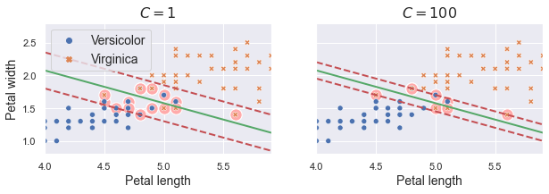

```python
soft_margin([1,100])
```

Like most hyper-parameters, it is often chosen using cross-validation.

Alike to maximal margin classifiers, SVC's only rely on a few observations, those on the margin or those that violate the margin (*Support Vectors*) - if they are on the correct side of the margin they dont change the classifier. This does mean that they are robust to observations far away from the hyperplane.

## Exercises

1. If $C$ is large, will there be more or less support vectors than if $C$ is small? Explain your answer.

## Exercise Answers

1. When the tuning parameter $C$ is large, then there are **more** support vectors, as many observations are involve in determining the hyperplane.

# Support Vector Machine

Aims to address the situation where the boundry between two classes is not linear.

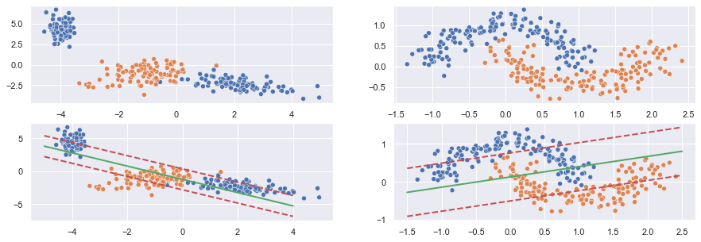

```python
import warnings
# TEMP
with warnings.catch_warnings():
    warnings.simplefilter("ignore")
    non_linear_examples()
```

We could consider enlarging the feature space using quadratic, cubic or higher-order polynomial functions, however the larger the number of features, the higher computational burden. Instead it is common to enlarge the feature space using an extension of a SVC termed a Support Vector Machine, which uses *kernels*.

The kernel apporach is an effiecent computational approach to enlarge our feature space to accommodate a non-linear boundary.

Using this we can represent the linear support vector classifier as, $f(x) = \beta_0 + \sum^n_{i=1}\alpha_i<x,x_i>$.

In the above case, for estimating the parameters $\alpha_1...,\alpha_n$ and $\beta_0$, we need the $n(n-1)/2$ inner products $<x,x_i>$ between all pairs of training observations. Similarly, if wanted to compute $f(x)$ we would need to the inner product between $x$ and each training point $x_i$.

However, $\alpha$ is nonzero only for support vectors, so if we have a collection of indicies of these support points we can do the following instead: $f(x) = \beta_0 + \sum_{i\in S}\alpha_i<x,x_i>$.

However instead of actually calculating the innerproduct, we could instead use a *generalisation*, $K(x,x_{i^{\prime}})$, where $K$ is a *kernel*.

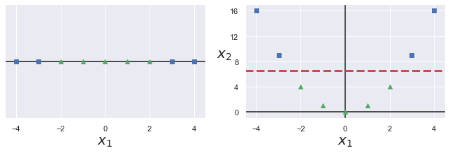

```python
# https://github.com/ageron/handson-ml2/blob/master/05_support_vector_machines.ipynb

X1D = np.linspace(-4, 4, 9).reshape(-1, 1)
X2D = np.c_[X1D, X1D**2]
y = np.array([0, 0, 1, 1, 1, 1, 1, 0, 0])

plt.figure(figsize=(10, 3))

plt.subplot(121)
plt.grid(True, which='both')
plt.axhline(y=0, color='k')
plt.plot(X1D[:, 0][y==0], np.zeros(4), "bs")
plt.plot(X1D[:, 0][y==1], np.zeros(5), "g^")
plt.gca().get_yaxis().set_ticks([])
plt.xlabel(r"$x_1$", fontsize=20)
plt.axis([-4.5, 4.5, -0.2, 0.2])

plt.subplot(122)
plt.grid(True, which='both')
plt.axhline(y=0, color='k')
plt.axvline(x=0, color='k')
plt.plot(X2D[:, 0][y==0], X2D[:, 1][y==0], "bs")
plt.plot(X2D[:, 0][y==1], X2D[:, 1][y==1], "g^")
plt.xlabel(r"$x_1$", fontsize=20)
plt.ylabel(r"$x_2$  ", fontsize=20, rotation=0)
plt.gca().get_yaxis().set_ticks([0, 4, 8, 12, 16])
plt.plot([-4.5, 4.5], [6.5, 6.5], "r--", linewidth=3)
plt.axis([-4.5, 4.5, -1, 17])

plt.subplots_adjust(right=1)

plt.show()
```

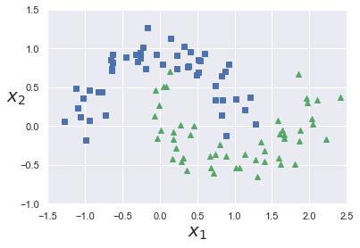

```python
# https://github.com/ageron/handson-ml2/blob/master/05_support_vector_machines.ipynb
from sklearn.datasets import make_moons
X, y = make_moons(n_samples=100, noise=0.15, random_state=42)

def plot_dataset(X, y, axes):
    plt.plot(X[:, 0][y==0], X[:, 1][y==0], "bs")
    plt.plot(X[:, 0][y==1], X[:, 1][y==1], "g^")
    plt.axis(axes)
    plt.grid(True, which='both')
    plt.xlabel(r"$x_1$", fontsize=20)
    plt.ylabel(r"$x_2$", fontsize=20, rotation=0)

plot_dataset(X, y, [-1.5, 2.5, -1, 1.5])
plt.show()
```

```python
# https://github.com/ageron/handson-ml2/blob/master/05_support_vector_machines.ipynb
from sklearn.datasets import make_moons
from sklearn.pipeline import Pipeline
from sklearn.preprocessing import PolynomialFeatures

polynomial_svm_clf = Pipeline([
        ("poly_features", PolynomialFeatures(degree=3)),
        ("scaler", StandardScaler()),
        ("svm_clf", LinearSVC(C=10, loss="hinge", random_state=42))
    ])

polynomial_svm_clf.fit(X, y)
```

```
Pipeline(steps=[('poly_features', PolynomialFeatures(degree=3)),
                ('scaler', StandardScaler()),
                ('svm_clf', LinearSVC(C=10, loss='hinge', random_state=42))])
```

```python
# 3d plot?
```

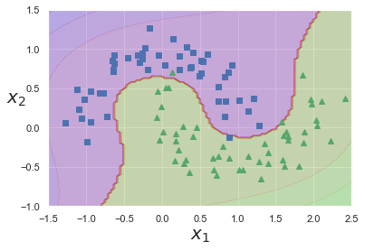

```python
# https://github.com/ageron/handson-ml2/blob/master/05_support_vector_machines.ipynb
def plot_predictions(clf, axes):
    x0s = np.linspace(axes[0], axes[1], 100)
    x1s = np.linspace(axes[2], axes[3], 100)
    x0, x1 = np.meshgrid(x0s, x1s)
    X = np.c_[x0.ravel(), x1.ravel()]
    y_pred = clf.predict(X).reshape(x0.shape)
    y_decision = clf.decision_function(X).reshape(x0.shape)
    plt.contourf(x0, x1, y_pred, cmap=plt.cm.brg, alpha=0.2)
    plt.contourf(x0, x1, y_decision, cmap=plt.cm.brg, alpha=0.1)

plot_predictions(polynomial_svm_clf, [-1.5, 2.5, -1, 1.5])
plot_dataset(X, y, [-1.5, 2.5, -1, 1.5])

plt.show()
```

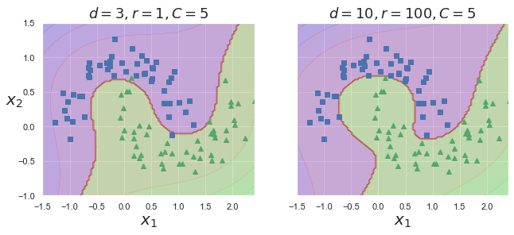

```python
from sklearn.svm import SVC

poly_kernel_svm_clf = Pipeline([
        ("scaler", StandardScaler()),
        ("svm_clf", SVC(kernel="poly", degree=3, coef0=1, C=5))
    ])
poly_kernel_svm_clf.fit(X, y)

poly100_kernel_svm_clf = Pipeline([
        ("scaler", StandardScaler()),
        ("svm_clf", SVC(kernel="poly", degree=10, coef0=100, C=5))
    ])
poly100_kernel_svm_clf.fit(X, y)

fig, axes = plt.subplots(ncols=2, figsize=(10.5, 4), sharey=True)

plt.sca(axes[0])
plot_predictions(poly_kernel_svm_clf, [-1.5, 2.45, -1, 1.5])
plot_dataset(X, y, [-1.5, 2.4, -1, 1.5])
plt.title(r"$d=3, r=1, C=5$", fontsize=18)

plt.sca(axes[1])
plot_predictions(poly100_kernel_svm_clf, [-1.5, 2.45, -1, 1.5])
plot_dataset(X, y, [-1.5, 2.4, -1, 1.5])
plt.title(r"$d=10, r=100, C=5$", fontsize=18)
plt.ylabel("")

plt.show()
```

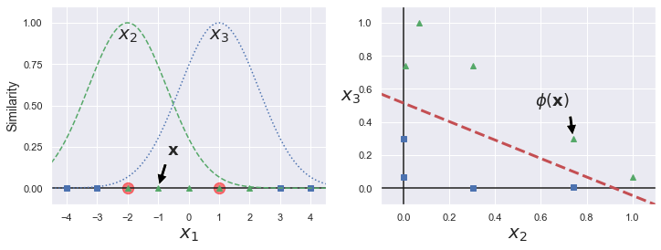

```python
# copied from https://github.com/ageron/handson-ml2/blob/master/05_support_vector_machines.ipynb
def gaussian_rbf(x, landmark, gamma):
    return np.exp(-gamma * np.linalg.norm(x - landmark, axis=1)**2)

gamma = 0.3

x1s = np.linspace(-4.5, 4.5, 200).reshape(-1, 1)
x2s = gaussian_rbf(x1s, -2, gamma)
x3s = gaussian_rbf(x1s, 1, gamma)

XK = np.c_[gaussian_rbf(X1D, -2, gamma), gaussian_rbf(X1D, 1, gamma)]
yk = np.array([0, 0, 1, 1, 1, 1, 1, 0, 0])

plt.figure(figsize=(10.5, 4))

plt.subplot(121)
plt.grid(True, which='both')
plt.axhline(y=0, color='k')
plt.scatter(x=[-2, 1], y=[0, 0], s=150, alpha=0.5, c="red")
plt.plot(X1D[:, 0][yk==0], np.zeros(4), "bs")
plt.plot(X1D[:, 0][yk==1], np.zeros(5), "g^")
plt.plot(x1s, x2s, "g--")
plt.plot(x1s, x3s, "b:")
plt.gca().get_yaxis().set_ticks([0, 0.25, 0.5, 0.75, 1])
plt.xlabel(r"$x_1$", fontsize=20)
plt.ylabel(r"Similarity", fontsize=14)
plt.annotate(r'$\mathbf{x}$',
             xy=(X1D[3, 0], 0),
             xytext=(-0.5, 0.20),
             ha="center",
             arrowprops=dict(facecolor='black', shrink=0.1),
             fontsize=18,
            )
plt.text(-2, 0.9, "$x_2$", ha="center", fontsize=20)
plt.text(1, 0.9, "$x_3$", ha="center", fontsize=20)
plt.axis([-4.5, 4.5, -0.1, 1.1])

plt.subplot(122)
plt.grid(True, which='both')
plt.axhline(y=0, color='k')
plt.axvline(x=0, color='k')
plt.plot(XK[:, 0][yk==0], XK[:, 1][yk==0], "bs")
plt.plot(XK[:, 0][yk==1], XK[:, 1][yk==1], "g^")
plt.xlabel(r"$x_2$", fontsize=20)
plt.ylabel(r"$x_3$  ", fontsize=20, rotation=0)
plt.annotate(r'$\phi\left(\mathbf{x}\right)$',
             xy=(XK[3, 0], XK[3, 1]),
             xytext=(0.65, 0.50),
             ha="center",
             arrowprops=dict(facecolor='black', shrink=0.1),
             fontsize=18,
            )
plt.plot([-0.1, 1.1], [0.57, -0.1], "r--", linewidth=3)
plt.axis([-0.1, 1.1, -0.1, 1.1])

plt.subplots_adjust(right=1)

plt.show()
```

[output not shown]

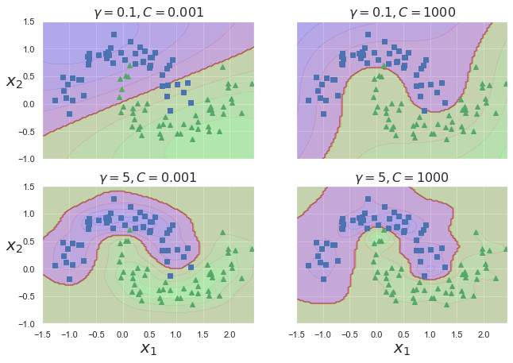

```python
x1_example = X1D[3, 0]
for landmark in (-2, 1):
    k = gaussian_rbf(np.array([[x1_example]]), np.array([[landmark]]), gamma)
    print("Phi({}, {}) = {}".format(x1_example, landmark, k))

rbf_kernel_svm_clf = Pipeline([
        ("scaler", StandardScaler()),
        ("svm_clf", SVC(kernel="rbf", gamma=5, C=0.001))
    ])
rbf_kernel_svm_clf.fit(X, y)

from sklearn.svm import SVC

gamma1, gamma2 = 0.1, 5
C1, C2 = 0.001, 1000
hyperparams = (gamma1, C1), (gamma1, C2), (gamma2, C1), (gamma2, C2)

svm_clfs = []
for gamma, C in hyperparams:
    rbf_kernel_svm_clf = Pipeline([
            ("scaler", StandardScaler()),
            ("svm_clf", SVC(kernel="rbf", gamma=gamma, C=C))
        ])
    rbf_kernel_svm_clf.fit(X, y)
    svm_clfs.append(rbf_kernel_svm_clf)

fig, axes = plt.subplots(nrows=2, ncols=2, figsize=(10.5, 7), sharex=True, sharey=True)

for i, svm_clf in enumerate(svm_clfs):
    plt.sca(axes[i // 2, i % 2])
    plot_predictions(svm_clf, [-1.5, 2.45, -1, 1.5])
    plot_dataset(X, y, [-1.5, 2.45, -1, 1.5])
    gamma, C = hyperparams[i]
    plt.title(r"$\gamma = {}, C = {}$".format(gamma, C), fontsize=16)
    if i in (0, 1):
        plt.xlabel("")
    if i in (1, 3):
        plt.ylabel("")

plt.show()
```

# Implimentation

There are three classes for SVM classification in Scikit-Learn (table below adapted from Géron(2017)<sup>1</sup>):

| Class | Time Complexity | Out-of-core Support | Kernel Trick |
| --- | --- | --- | --- |
| LinearSVC | 0(*m* x *n*) | No | No |
| SGDClassifier | 0(*m* x *n*) | Yes | No |
| SVC | 0(*m*<sup>2</sup> x *n*) to 0(*m*<sup>3</sup> x *n*) | No | Yes |

1. Standardize the features
2. SVM

## Dimensionality Reduction and SVM

In order to reduce a models complexity, run time, and potential for overfitting to the training data, dimension reduction techniques can be used. Broadly they can be grouped into methods that create a subset of the original set of features (Feature Selection) and methods that create new synthetic features through combining the original features and discarding less important ones (Feature Extraction). Essentially we want to remove "uninformative infromation" and retain useful bits<sup>1</sup>. If you have too many features, it may be that some of them are highly correlated and therefore redundant. Therefore we can either select just some of them, or compress them onto a lower dimensional subspace<sup>2</sup>.

1. Zheng, A., & Casari, A. (2018). Feature Engineering for Machine Learning: Principles and Techniques for Data Scientists. " O'Reilly Media, Inc.".
2. Raschka, 2016

## Filtering

A computationally efficient method of selecting features is to use a filter method. Filter methods aim to remove features with a low potential to predict outputs; usually though univariate analysis before classification. A filter could be a threshold set on each features variance, or the correlation or mutual information between each feature and the response variable. Although filters are computationally efficient comparative to other feature selection methods, they are independent of the model chosen so should be used conservatively to ensure data is not removed that a model may find useful<sup>1</sup>.

### Variance Threshold

VarianceThreshold is a simple baseline approach to feature selection. It removes all features whose variance doesn’t meet some threshold.

1. Zheng, A., & Casari, A. (2018). Feature Engineering for Machine Learning: Principles and Techniques for Data Scientists. " O'Reilly Media, Inc.".

```python
#from sklearn.feature_selection import VarianceThreshold
#from itertools import compress
#from collections import defaultdict
#import pprint
#pp = pprint.PrettyPrinter()
#
#sel = VarianceThreshold(threshold=.8)
#sel.fit(X_train)
#
# get boolian list of what is kept and what not
#keep_bool = sel.get_support()
# get index of false values
#remove_index = [i for i, x in enumerate(keep_bool) if not x]
#
# merge multiindex feature labels into 1 label list
#feat_labels = reduced_features.columns
#remove_list = list(feat_labels[remove_index])
#
#print(color.BOLD+color.UNDERLINE+'Features and Channels Removed ('+str(len(remove_index))+')\n'+color.END)
#pp.pprint(remove_list)
```

### Embedded Methods

Instead of being independent, feature selection methods can be embedded in the model training process. An example would be the l1 regularizer for linear models, which imposes a sparsity constraint on the model to ensure a model favours fewer features. These methods are efficient and specific to the chosen model, but are not as powerful at wrapper methods (discussed next)<sup>1</sup>.

1. Zheng, A., & Casari, A. (2018). Feature Engineering for Machine Learning: Principles and Techniques for Data Scientists. " O'Reilly Media, Inc.".

## Wrapper Methods

Wrapper methods are also specific to the chosen model as they directly optimise the accuracy of a classifier by trying subsets of features. This enables keeping features that are useful in combination with others, even if uninformative in isolation<sup>1</sup>. Wrapper methods are the most computationally expensive, especially when used with nonlinear classifiers.

1. Zheng, A., & Casari, A. (2018). Feature Engineering for Machine Learning: Principles and Techniques for Data Scientists. " O'Reilly Media, Inc.".

## Imballanced Data and SVM

## Multi-class

Tree-based classifiers are inherently multiclass whereas other machine learning algorithms are able to be extended to multi-class classification using techniques such as the One-versus-Rest or One-versus-One methods<sup>1</sup>.

**One-vs-the-rest (or one-verses-all)** is were you train a classifier for each class and select the class from the classifier that outputs the highest score<sup>1</sup>. As each class is fitted against all other classes for each classifier, it is relatively interpretable<sup>2</sup>.

1. Géron, A. (2017). Hands-on machine learning with Scikit-Learn and TensorFlow: concepts, tools, and techniques to build intelligent systems. " O'Reilly Media, Inc.".
2. https://scikit-learn.org/stable/modules/generated/sklearn.multiclass.OneVsRestClassifier.html

```python
#from sklearn.multiclass import OneVsRestClassifier
#
#multi_pipe_svc_rbf = Pipeline([
#    ('scl', StandardScaler()),
#    ('clf', OneVsRestClassifier(SVC(C=100,
#                                    kernel='rbf',
#                                    gamma = 'auto',
#                                    class_weight = 'balanced',
#                                    random_state=RANDOM_STATE)))])

#multi_pipe_svc_rbf.fit(multi_X_train, multi_y_train)
#print('Validation Accuracy: %.3f' % multi_pipe_svc_rbf.score(multi_X_val, multi_y_val))
```

Another strategy is to use a **OneVsOneClassifer**. This trains $N \times (N-1) / 2$ classifiers by comparing each class against each other so when a prediction is made, the class that is selected the most is chosen<sup>1</sup> (we'll get more onto *Bagging* next week). It is useful where algorithms do not scale well with data size (such as SVM) because each training and prediction is only needed to be run on a small subset of the data for each classifer<sup>1,2</sup>.

1. Géron, A. (2017). Hands-on machine learning with Scikit-Learn and TensorFlow: concepts, tools, and techniques to build intelligent systems. " O'Reilly Media, Inc.".
2. https://scikit-learn.org/stable/modules/generated/sklearn.multiclass.OneVsRestClassifier.html

```python
#from sklearn.multiclass import OneVsOneClassifier
#
#multi_pipe_svc_rbf = Pipeline([
#    ('scl', StandardScaler()),
#    ('clf', OneVsOneClassifier(SVC(C=100,
#                                   kernel='rbf',
#                                   gamma = 'auto',
#                                   class_weight = 'balanced',
#                                   random_state=RANDOM_STATE)))])
#
#multi_pipe_svc_rbf.fit(multi_X_train, multi_y_train)
#print('Validation Accuracy: %.3f' % multi_pipe_svc_rbf.score(multi_X_val, multi_y_val))
```

```python
#multi_pipe_svc_rbf.fit(multi_vis_data, multi_y_train)
#
#plot_decision_regions(multi_vis_data,
#                      multi_y_train,
#                      clf = multi_pipe_svc_rbf)
#
#plt.xlabel(x_axis_label)
#plt.ylabel(y_axis_label)
#plt.xlim(0,.6)
#plt.ylim(0,1.)
#plt.show()
```

## Majority Voting

A group of classifiers don't have to all be SVM's. Indeed Scikitlearn has a VotingClassifier where multipule classification pipelines can be combined to create an even better classifier that aggregates predictions. This aggregation can be done by simply selecting the class label that has been predicted by the majority of the classifiers (more than 50% of votes) for 'hard voting'. Majority vote refers to binary class decisions but can be generalized to a multi-class setting using 'plurality voting'. Particular classifiers return the probability of a predicted class label via the predict_proba method and this can be used for 'soft voting' instead of class labels<sup>1</sup>.

Ensemble methods work best when the predictors are as independent as possible, so one way of achiving this is to get diverse classifiers. This increases the chance they each make different types of errors which in combination will improve the overall accuracy<sup>2</sup>.

**NOTE**

```python
# TODO: Replace the Tree with one of the other classifiers they have already learnt

#%%time
#from sklearn.preprocessing import StandardScaler
#from sklearn.ensemble import VotingClassifier
#from sklearn.pipeline import Pipeline
#from sklearn.linear_model import LogisticRegression
#from sklearn.svm import SVC
#from sklearn.tree import DecisionTreeClassifier
#from sklearn.model_selection import cross_val_score
#from imblearn.under_sampling import NeighbourhoodCleaningRule
#from sklearn.decomposition import PCA
#import timeit
#from sklearn.model_selection import StratifiedKFold
#from sklearn.metrics import confusion_matrix, precision_score, recall_score, f1_score, accuracy_score, make_scorer
#
#clf1 = Pipeline([('scl', StandardScaler()),
#                 ('clf', SVC(kernel='rbf',
#                             gamma='auto',
#                             random_state=RANDOM_STATE,
#                             probability = True))])

#clf2 = Pipeline([('scl', StandardScaler()),
#                 ('clf', LogisticRegression(solver='liblinear',
#                                            random_state=RANDOM_STATE))
#])

#clf3 = DecisionTreeClassifier(random_state=RANDOM_STATE)
#
#clf_labels = ['SVM', # Support Vector Machine
#              'LR', # LogisticRegression
#              'DT'] # Decision Tree
#
# Majority Rule Voting
#hard_mv_clf = VotingClassifier(estimators=[(clf_labels[0],clf1),
#                                           (clf_labels[1],clf2),
#                                           (clf_labels[2],clf3)],
#                              voting='hard')
#
#soft_mv_clf = VotingClassifier(estimators=[(clf_labels[0],clf1),
#                                           (clf_labels[1],clf2),
#                                           (clf_labels[2],clf3)],
#                               voting='soft')
#
#clf_labels += ['Hard Majority Voting', 'Soft Majority Voting']
#all_clf = [clf1, clf2, clf3, hard_mv_clf, soft_mv_clf]
#
#print(color.BOLD+color.UNDERLINE+'Validation Scores\n'+color.END)
#for clf, label in zip(all_clf, clf_labels):
#    start = timeit.default_timer() # TIME STUFF
#
#    clf.fit(X_train, y_train)
#
#    y_pred = clf.predict(X_val)
#    scores = f1_score(y_val, y_pred)
#    print(color.BOLD+label+color.END)
#    print("Score: %0.3f"
#          % scores)
    # TIME STUFF
#    stop = timeit.default_timer()
#    print("Run time:", np.round((stop-start)/60,2),"minutes")
#    print()
```

```python
#%%time
#from sklearn.metrics import roc_curve
#from sklearn.metrics import auc
#
# remove the hard voting because doesnt have predict proba
#del clf_labels[3], all_clf[3]
#
#colors = ['black', 'orange', 'blue', 'green']
#linestyles = [':', '--', '-.', '-']
#for clf, label, clr, ls \
#        in zip(all_clf,
#               clf_labels, colors, linestyles):
#
    # assuming the label of the positive class is 1
#    y_pred = clf.fit(X_train,
#                          y_train).predict_proba(X_test)[:, 1]
#    fpr, tpr, thresholds = roc_curve(y_true=y_test,
#                                     y_score=y_pred)
#    roc_auc = auc(x=fpr, y=tpr)
#    plt.plot(fpr, tpr,
#             color=clr,
#             linestyle=ls,
#             label='%s (auc = %0.2f)' % (label, roc_auc))
#
#plt.legend(loc='lower right')
#plt.plot([0, 1], [0, 1],
#         linestyle='--',
#        color='gray',
#         linewidth=2)

#plt.xlim([-0.1, 1.1])
#plt.ylim([-0.1, 1.1])
#plt.grid(alpha=0.5)
#plt.xlabel('False positive rate (FPR)')
#plt.ylabel('True positive rate (TPR)')

#plt.savefig(os.path.join(IMAGE_DIR, 'Pipeline_Rocs.png'), dpi=300)
#plt.show()
```

# References

1. Fisher, R. A. (1936). The use of multiple measurements in taxonomic problems. Annals of eugenics, 7(2), 179-188.
2. James, Gareth, Daniela Witten, Trevor Hastie, and Robert Tibshirani. An introduction to statistical learning. Vol. 112. New York: springer, 2013.
3. Géron, A. (2017). Hands-on machine learning with Scikit-Learn and TensorFlow: concepts, tools, and techniques to build intelligent systems. " O'Reilly Media, Inc.".

# NOTES

- https://scikit-learn.org/stable/auto_examples/exercises/plot_iris_exercise.html#sphx-glr-auto-examples-exercises-plot-iris-exercise-py